# Project - Number Of Steps Taken Weekend vs Weekday

JRSrednas

November 24, 2017

## Importing Data and Profiling Data Set

```r
setwd("C:/Users/jrsanders/Documents/2017_Reproduce/repdata_data_activity")
library(lubridate)
library(dplyr)
library(lattice)
activ<-data.frame()
activ<- read.csv("activity.csv")
dim(activ)
```

```
## [1] 17568     3
```

```r
head(activ)
```

```
##   steps       date interval
## 1    NA 2012-10-01        0
## 2    NA 2012-10-01        5
## 3    NA 2012-10-01       10
## 4    NA 2012-10-01       15
## 5    NA 2012-10-01       20
## 6    NA 2012-10-01       25
```

```r
colnames(activ)
```

```
## [1] "steps"    "date"     "interval"
```

## Number Of NA’s in the data set

```r
colSums(is.na(activ))
```

```
##    steps     date interval
##     2304        0        0
```

```r
# str(activ)
#### Part 0 - Quantity of Missing Values in Dataset
print(colSums(is.na(activ)))
```

```
##    steps     date interval
##     2304        0        0
```

### Creating Complete Cases Thus No Imputation

```r
cact <- activ[complete.cases(activ),]
intstps<- aggregate(steps ~ interval , cact, mean)
```

#### Time Series Plot of Average Number Of Steps Taken

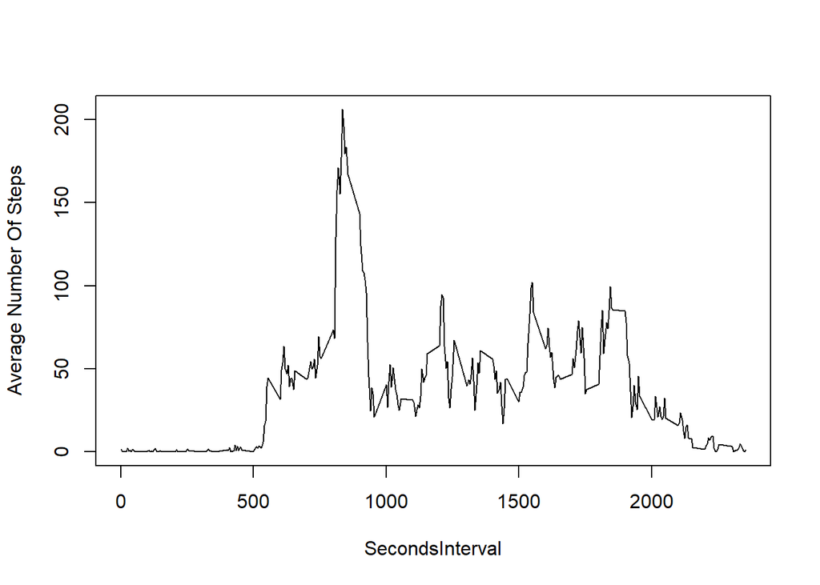

```r
plot(intstps$interval,intstps$steps, type = "l",xlab="SecondsInterval",
     ylab="Average Number Of Steps")
```

#### The 5 Minute Interval That on Average Contains the Max Number of Steps

```r
local <- vector()
local <- intstps$steps
print(intstps[which.max(local),])
```

```
##     interval    steps
## 104      835 206.1698
```

### Typing The Date and Steps Fields

```r
activ$date<- as.Date(activ$date )
activ$steps <- as.numeric(activ$steps)
```

#### Determining the mean and median of steps taken each day

```r
part1<-data.frame()
##### Calculating the Total Amount of Steps Per Day
part1<-activ %>% group_by(date) %>% summarize(sum(steps,na.rm=TRUE))
print(part1)
```

```
## # A tibble: 61 x 2
##          date `sum(steps, na.rm = TRUE)`
##        <date>                      <dbl>
##  1 2012-10-01                          0
##  2 2012-10-02                        126
##  3 2012-10-03                      11352
##  4 2012-10-04                      12116
##  5 2012-10-05                      13294
##  6 2012-10-06                      15420
##  7 2012-10-07                      11015
##  8 2012-10-08                          0
##  9 2012-10-09                      12811
## 10 2012-10-10                       9900
## # ... with 51 more rows
```

```r
names(part1)[2] <- "sumsteps"
summary(part1$sumsteps)
```

```
##    Min. 1st Qu.  Median    Mean 3rd Qu.    Max.
##       0    6778   10395    9354   12811   21194
```

```r
################### Mean and Median Zeros Filtered Out#######
ppart<- subset(part1, sumsteps > 0)
average <- mean(ppart$sumsteps,na.rm=TRUE)
medianmark <- median(ppart$sumsteps,na.rm=TRUE)
summary(ppart$sumsteps);print(average); print(medianmark)
```

```
##    Min. 1st Qu.  Median    Mean 3rd Qu.    Max.
##      41    8841   10765   10766   13294   21194
```

```
## [1] 10766.19
```

```
## [1] 10765
```

#### Histogram of The Total Numbers of Steps Taken Each Day - No Imputation

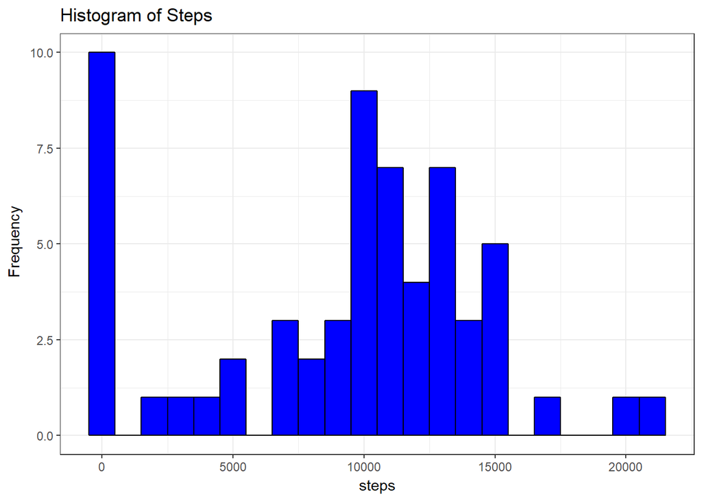

```r
library(ggplot2)
ggplot(part1,aes(x=sumsteps)) +
  geom_histogram(fill = "blue", color = "black", binwidth = 1000) +
  labs(title = "Histogram of Steps", x= "steps", y = " Frequency") + theme_bw()
```

```r
# head(part1)
```

### Code To Describe and Show Imputing Strategy

#### Imputation of data - Create a table containg the mean for each 5 minute interval. A dataframe containing time intervals and the correspond average is created.

```r
cact <- activ[complete.cases(activ),]
intstps<- aggregate(steps ~ interval , cact, mean)
rowcount<- nrow(activ)
# print(rowcount)
### THE IMPUTATION OF THE DATA SET
```

#### Identify the row that contains NA steps and the corresponding time interval. for all NA’s. Populate the NA’s with the average time for that interval of time.

```r
impactiv2 <- read.csv("activity.csv")
count <- nrow(impactiv2)
   for ( i in 1:rowcount) {
     if ( is.na(impactiv2$steps[i])) {

       intervaltime = impactiv2$interval[i]
       rowid = which(intstps$interval == intervaltime)
       avsteps = intstps$steps[rowid]
  ##### Back in The Main Table
      impactiv2$steps[i]<- avsteps
     } else {
       # print(Sys.time())
     }
     # print("End of For Loop")
   }
print(head(impactiv2,10))
```

```
##        steps       date interval
## 1  1.7169811 2012-10-01        0
## 2  0.3396226 2012-10-01        5
## 3  0.1320755 2012-10-01       10
## 4  0.1509434 2012-10-01       15
## 5  0.0754717 2012-10-01       20
## 6  2.0943396 2012-10-01       25
## 7  0.5283019 2012-10-01       30
## 8  0.8679245 2012-10-01       35
## 9  0.0000000 2012-10-01       40
## 10 1.4716981 2012-10-01       45
```

```r
summary(is.na(impactiv2))
```

```
##    steps            date          interval
##  Mode :logical   Mode :logical   Mode :logical
##  FALSE:17568     FALSE:17568     FALSE:17568
```

```r
print(colSums(is.na(impactiv2)))
```

```
##    steps     date interval
##        0        0        0
```

```r
part2v <-data.frame()
##### Calculating the Total Amount of Steps Per Day                       #
part2v <-impactiv2 %>% group_by(date) %>% summarize(sum(steps,na.rm=TRUE))
head(part2v,6)
```

```
## # A tibble: 6 x 2
##         date `sum(steps, na.rm = TRUE)`
##       <fctr>                      <dbl>
## 1 2012-10-01                   10766.19
## 2 2012-10-02                     126.00
## 3 2012-10-03                   11352.00
## 4 2012-10-04                   12116.00
## 5 2012-10-05                   13294.00
## 6 2012-10-06                   15420.00
```

```r
names(part2v)[2] <- "sumsteps"
head(part2v,3)
```

```
## # A tibble: 3 x 2
##         date sumsteps
##       <fctr>    <dbl>
## 1 2012-10-01 10766.19
## 2 2012-10-02   126.00
## 3 2012-10-03 11352.00
```

```r
summary(part2v$sumsteps)
```

```
##    Min. 1st Qu.  Median    Mean 3rd Qu.    Max.
##      41    9819   10766   10766   12811   21194
```

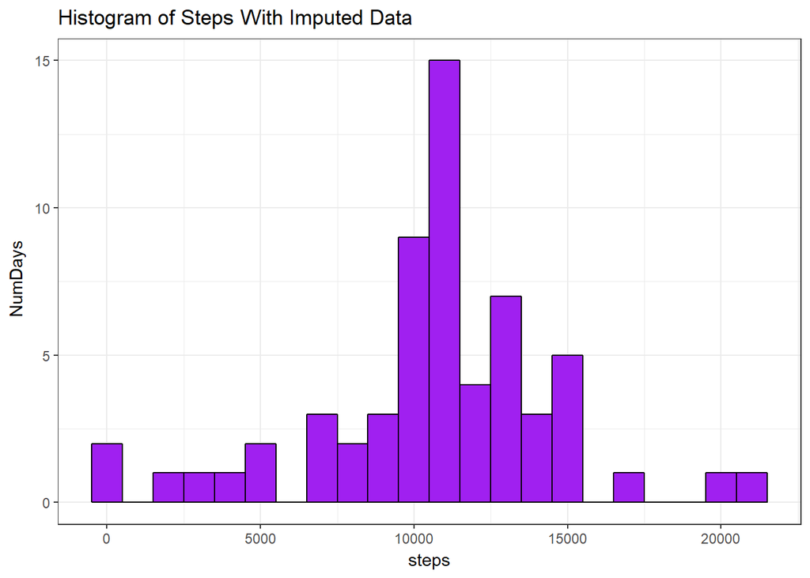

```r
library(ggplot2)
ggplot(part2v, aes(x=sumsteps)) +
  geom_histogram(fill = "purple", color = "black", binwidth = 1000) +
  labs(title = "Histogram of Steps With Imputed Data", x= "steps", y = " NumDays") + theme_bw()
```

#### Adding days of the week to imputed data

```r
impactiv2$day <- weekdays(as.Date(impactiv2$date))
dayys <- weekdays(as.Date(impactiv2$date))
dim(impactiv2)
```

```
## [1] 17568     4
```

```r
head(impactiv2,3)
```

```
##       steps       date interval    day
## 1 1.7169811 2012-10-01        0 Monday
## 2 0.3396226 2012-10-01        5 Monday
## 3 0.1320755 2012-10-01       10 Monday
```

##### Adding Weekend and Weekday Column

```r
 for ( i in 1:17568 ){
       if  (impactiv2[i,4] == "Saturday") {

         impactiv2[i,5] = "Weekend"
       } else if (impactiv2[i,4] == "Sunday") {

         impactiv2[i,5] = "Weekend"
       }
       else    {

         impactiv2[i,5] = "Weekday"
       }  #### END OF ELSE
 }
```

```r
chkpt <-subset(impactiv2,day== "Sunday" | day == "Saturday" | day == "Monday")
head(chkpt,4)
```

```
##       steps       date interval    day      V5
## 1 1.7169811 2012-10-01        0 Monday Weekday
## 2 0.3396226 2012-10-01        5 Monday Weekday
## 3 0.1320755 2012-10-01       10 Monday Weekday
## 4 0.1509434 2012-10-01       15 Monday Weekday
```

```r
# weekdays <- c("Monday","Tuesday","Wednesday","Thursday","Friday")
imputesteps <- aggregate(steps ~ interval + V5, impactiv2,mean )
```

### Panel Plot Averaged Steps Across Weekends and Weekdays

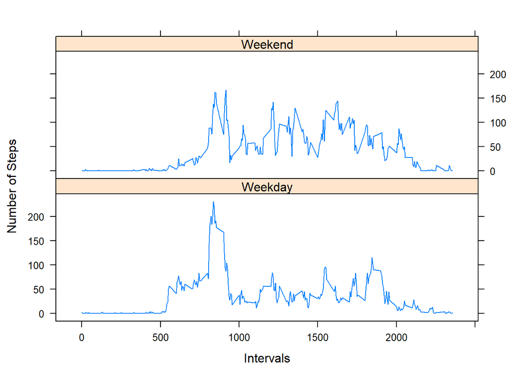

```r
xyplot(imputesteps$steps ~ imputesteps$interval | imputesteps$V5, impactiv2, type = "l", layout =c(1,2),
            xlab = "Intervals", ylab = "Number of Steps")
```

### Results

The graph above can be used to see the difference in between Weedend steps and Weekday steps taken.One can see there is a period during the week, where more steps appear to be taken but the changes. More steps appear to be taken on the weekend after 1000th interval.